# Destino Espírito Santo: um breve estudo sobre imigração a partir de dados da Polícia Federal.

Autor

Lucas Barros

# 1 Introdução

Este relatório apresenta uma análise dos dados de migração da Polícia Federal (SISMIGRA), com foco no estado do Espírito Santo.

O presente relatório possui apenas objetivo didático, para fins de estudo de Análise Exploratória de Dados (EDA) e não deve ser utilizado para fins comerciais ou de tomada de decisão.

Os dados utilizados neste relatório foram obtidos a partir do portal de dados abertos do governo brasileiro, e estão disponíveis para consulta pública, apartir do link (https://dados.gov.br/dados/conjuntos-dados/sismigra—sistema-de-registro-nacional-migratorio)

— **Fonte dos dados**: SISMIGRA - Sistema de Registro Nacional Migratório

— **Período analisado**: Janeiro e Fevereiro de 2026

# 2 Carregamento dos dados

Os dados foram carregados a partir de arquivos CSV disponibilizados no portal de dados abertos:

[Dados de Migração - SISMIGRA](https://dados.gov.br/dados/conjuntos-dados/sismigra---sistema-de-registro-nacional-migratorio)

Para leitura e manipulação dos dados, foi utilizada a biblioteca **pandas**, amplamente utilizada em análise de dados.

## 2.1 Tratamento e Consolidação dos Dados

Após o carregamento, os dados foram enriquecidos com uma variável temporal e consolidados em uma única base.

|  | UF | NACIONALIDADE | CLASSIFICACAO | QTD | MES |
| --- | --- | --- | --- | --- | --- |
| 0 | SP | BOLÍVIA | Residente | 106567 | 2026-01 |
| 1 | SP | INDIA | Residente | 1445 | 2026-01 |
| 2 | SP | ANGOLA | Temporário | 8219 | 2026-01 |
| 3 | SP | CHILE | Residente | 15612 | 2026-01 |
| 4 | SP | JAPÃO | Residente | 36258 | 2026-01 |

Essa etapa permitiu a criação de uma base única e ordenada, facilitando análises temporais.

## 2.2 Construção da Variável de Fluxo Migratório

Para permitir a análise da dinâmica de entrada de migrantes, foi criada a variável QTD_DIF, que representa a variação mensal dos registros, uma vez que descobrimos que o sistema da Polícia Federal registra o consolidado cumulado, e não o fluxo mensal.

|  | UF | NACIONALIDADE | CLASSIFICACAO | QTD | MES | QTD_DIF |
| --- | --- | --- | --- | --- | --- | --- |
| 0 | SP | BOLÍVIA | Residente | 106567 | 2026-01 | 106567.0 |
| 1 | SP | INDIA | Residente | 1445 | 2026-01 | 1445.0 |
| 2 | SP | ANGOLA | Temporário | 8219 | 2026-01 | 8219.0 |
| 3 | SP | CHILE | Residente | 15612 | 2026-01 | 15612.0 |
| 4 | SP | JAPÃO | Residente | 36258 | 2026-01 | 36258.0 |

A variável QTD_DIF foi criada para representar a variação entre períodos consecutivos, permitindo a análise do fluxo mensal de entradas.

## 2.3 Classificação do Comportamento Migratório

Com base nessa variável, foi proposta uma interpretação analítica do comportamento dos dados ao longo do tempo:

CRESCIMENTO: aumento no número de registros ESTÁVEL: ausência de variação REDUÇÃO: diminuição no número de registros

Essa classificação permite transformar os dados em informações analíticas, facilitando a identificação de padrões e tendências migratórias.

|  | UF | NACIONALIDADE | CLASSIFICACAO | QTD | MES | QTD_DIF | TIPO_MOVIMENTO |
| --- | --- | --- | --- | --- | --- | --- | --- |
| 0 | SP | BOLÍVIA | Residente | 106567 | 2026-01 | 106567.0 | CRESCIMENTO |
| 1 | SP | INDIA | Residente | 1445 | 2026-01 | 1445.0 | CRESCIMENTO |
| 2 | SP | ANGOLA | Temporário | 8219 | 2026-01 | 8219.0 | CRESCIMENTO |
| 3 | SP | CHILE | Residente | 15612 | 2026-01 | 15612.0 | CRESCIMENTO |
| 4 | SP | JAPÃO | Residente | 36258 | 2026-01 | 36258.0 | CRESCIMENTO |
| 5 | SP | PORTUGAL | Residente | 65778 | 2026-01 | 65778.0 | CRESCIMENTO |
| 6 | SP | BOLÍVIA | Temporário | 36003 | 2026-01 | 36003.0 | CRESCIMENTO |
| 7 | SP | CHINA | Residente | 38309 | 2026-01 | 38309.0 | CRESCIMENTO |
| 8 | SP | CORÉIA DO SUL | Residente | 15895 | 2026-01 | 15895.0 | CRESCIMENTO |
| 9 | SP | ALEMANHA | Residente | 10017 | 2026-01 | 10017.0 | CRESCIMENTO |

# 3 Análise Descritiva

O conjunto de dados está estruturado com as seguintes variáveis:

- **UF**: Unidade da Federação
- **NACIONALIDADE**: País de origem do migrante
- **CLASSIFICACAO**: Tipo de permanência
- **QTD**: Quantidade acumulada
- **MES**: Referência temporal
- **QTD_DIF**: Variação mensal (fluxo estimado)
- **TIPO_MOVIMENTO**: Classificação do movimento (CRESCIMENTO, ESTÁVEL, REDUÇÃO)

# 4 Análise de Migração para o Espírito Santo

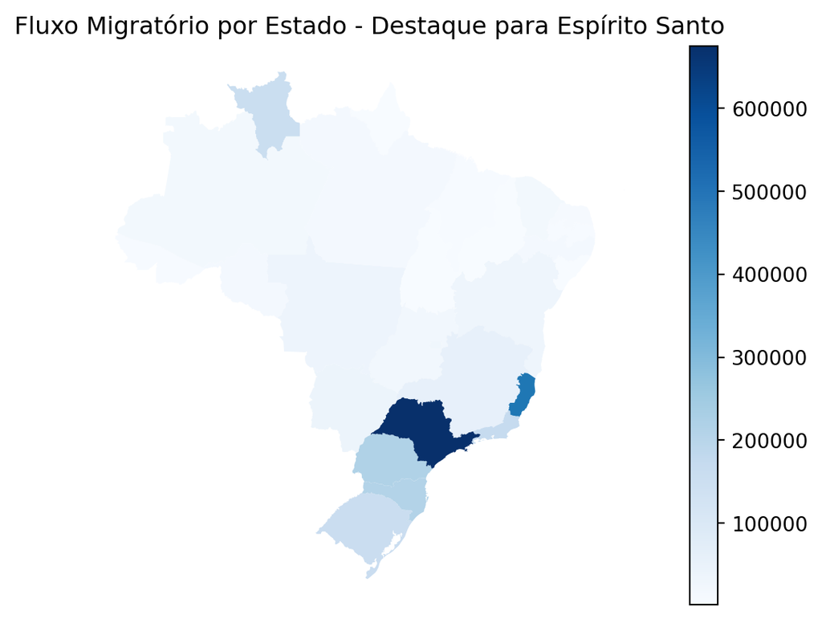

Inicialmente, os dados foram filtrados para o estado do Espírito Santo, permitindo uma análise mais focada e detalhada sobre as dinâmicas migratórias específicas do Estado.

|  | UF | NACIONALIDADE | CLASSIFICACAO | QTD | MES | QTD_DIF | TIPO_MOVIMENTO |
| --- | --- | --- | --- | --- | --- | --- | --- |
| 3620 | ES | CUBA | Residente | 266 | 2026-01 | 266.0 | CRESCIMENTO |
| 3621 | ES | ESTADOS UNIDOS | Residente | 415 | 2026-01 | 415.0 | CRESCIMENTO |
| 3622 | ES | VENEZUELA | Temporário | 919 | 2026-01 | 919.0 | CRESCIMENTO |
| 3623 | ES | TUNÍSIA | Residente | 10 | 2026-01 | 10.0 | CRESCIMENTO |
| 3624 | ES | PORTUGAL | Residente | 1162 | 2026-01 | 1162.0 | CRESCIMENTO |

Em seguida, os registros foram ordenados com base no fluxo migratório:

|  | UF | NACIONALIDADE | CLASSIFICACAO | QTD | MES | QTD_DIF | TIPO_MOVIMENTO |
| --- | --- | --- | --- | --- | --- | --- | --- |
| 3626 | ES | VENEZUELA | Residente | 1238 | 2026-01 | 1238.0 | CRESCIMENTO |
| 3624 | ES | PORTUGAL | Residente | 1162 | 2026-01 | 1162.0 | CRESCIMENTO |
| 3622 | ES | VENEZUELA | Temporário | 919 | 2026-01 | 919.0 | CRESCIMENTO |
| 3636 | ES | ITÁLIA | Residente | 762 | 2026-01 | 762.0 | CRESCIMENTO |
| 3629 | ES | COLÔMBIA | Residente | 702 | 2026-01 | 702.0 | CRESCIMENTO |
| ... | ... | ... | ... | ... | ... | ... | ... |
| 10888 | ES | EQUADOR | Temporário | 16 | 2026-02 | -2.0 | REDUÇÃO |
| 10868 | ES | CHINA | Residente | 320 | 2026-02 | -2.0 | REDUÇÃO |
| 11010 | ES | GANA | Temporário | 4 | 2026-02 | -3.0 | REDUÇÃO |
| 11061 | ES | NIGÉRIA | Temporário | 3 | 2026-02 | -3.0 | REDUÇÃO |
| 10862 | ES | COLÔMBIA | Temporário | 477 | 2026-02 | -5.0 | REDUÇÃO |

475 rows × 7 columns

A análise evidencia que o estado do Espírito Santo, durante os meses de Janeiro à Fevereiro, predominância de crescimento migratório, com destaque para: Venezuela,Portugal e Itália. Sendo estes os países que deram entrada de Residentes.

|  | CLASSIFICACAO | QTD_DIF |
| --- | --- | --- |
| 1 | Residente | 9233.0 |
| 2 | Temporário | 2522.0 |
| 0 | Provisório | 395.0 |

Observa-se que a dinâmica migratória no Estado do Espírito Santo não é homogênea, variando conforme nacionalidade e tipo de permanência.

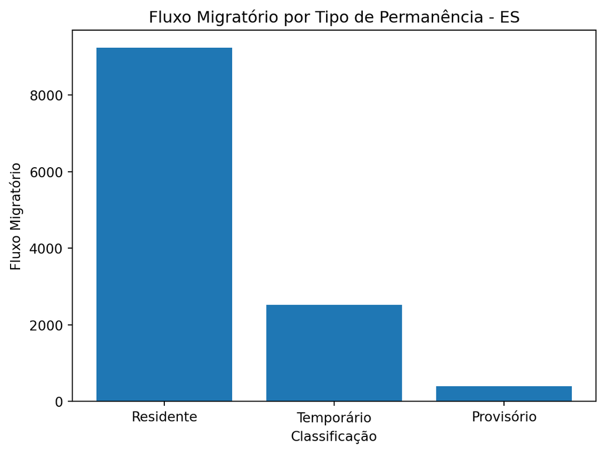